# Sampling Distributions (Section 3.1)

Day 9

Claire Kelling

Carleton College  
STAT 120 - Fall 2026

## Question of the Day

What’s a song you’ve had on repeat lately?

## Today’s Topics

Logistics:

- Quiz 1 is graded, but waiting on one makeup quiz to be scheduled (corrections will be due 2 weeks after grades are posted)
- Short report:
  - Resume data: read about the design of the study! This is important!
  - “we” is absolutely okay to use!
  - Keep it simple/focused!

Topics covered today:

- Finishing up bivariate analysis
- Starting Sampling Distributions
  - Point estimates
  - Uncertainty quantification

# Introduction

## Reminder: Big Picture

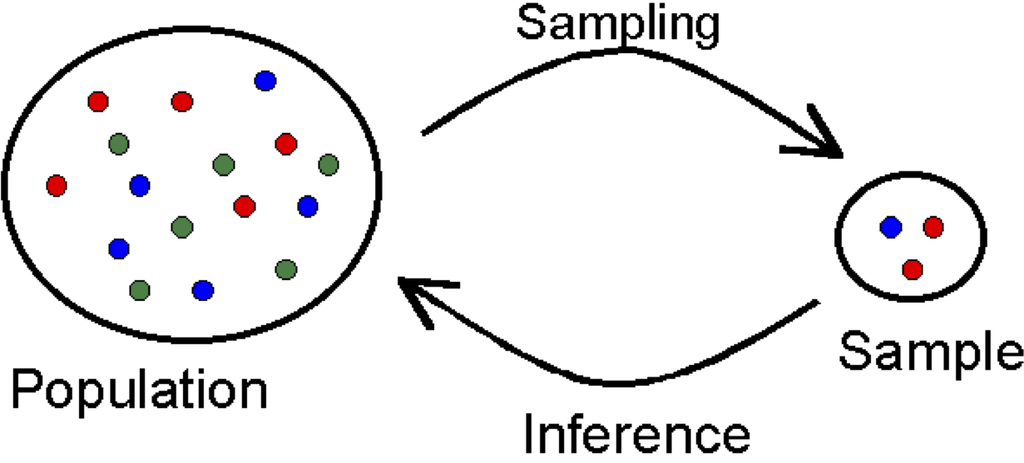

- **Now:** Inference
  - How do we make conclusions about a population, given a sample
  - Example of an inferential statement from a sample: “90% of all humans think my dog is cute, with a **margin of error of 2%**”
  - (Called uncertainty quantification)

## Example: Political Polling

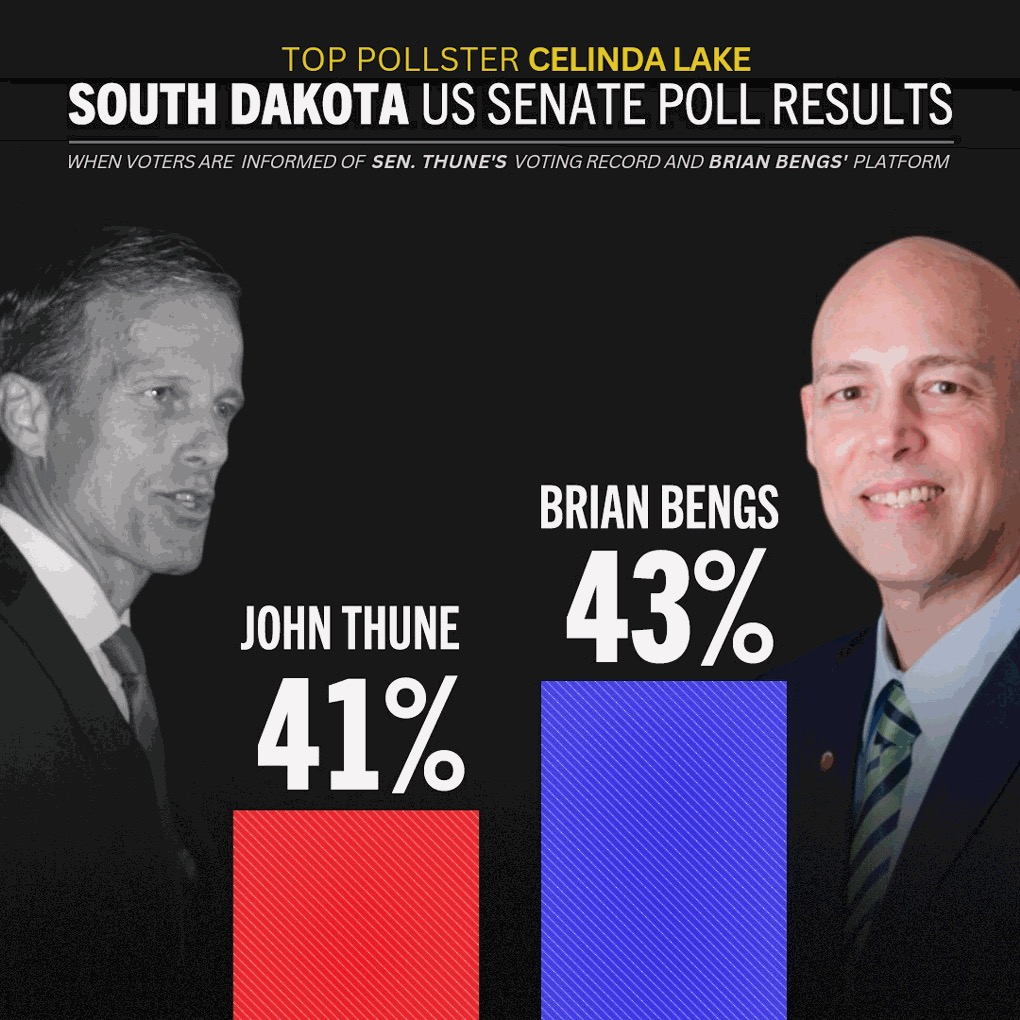

Using a sample, the poll estimated the percentage of people who will vote for Brian Bengs or John Thune.

**What are some potential problems with this image?**

- No uncertainty quantification (“margin of error”)
- No sample size or details on the sample at all
- Interesting choice of y-axis
- Potentially other flaws as well…

**Source:** (Thanks Mom!) Brian Bengs for US Senate Twitter

## Example: Russian Political Polling

- Survey of Russian citizens on whether they believed their government tried to influence the 2016 US election.
- The survey was taken in Spring 2018 by Pew Research.

Sample Details:

- 506 Russian citizens surveyed
- Excluding people who did not know (71 people)
- 359 people thought Russia did not influence the election, 76 did

## Example: Russian Political Polling

- What is the population of this study? Russian citizens
- What is the *population* proportion of those who thought they **did** try to influence the election? Unknown.
- *Sample* proportion of those who thought they **did** try to influence the election: $\hat{p} = \frac{76}{76 + 359} = 17.5\%$

## Parameters vs Statistics

**Definition**

**Parameter**: a number characterizing the population

- ex: population proportion

**Definition**

**Statistic**: a number that is computed from the data you have

- ex: sample proportion
- We use the sample statistic to make **inference** about the population parameter
  - Calculate the statistic to estimate the parameter
  - Uncertainty quantification: important step!

## Notation Review

|  | Parameter | Statistic |
| --- | --- | --- |
| Mean | $\mu$ (mu) | $\bar{x}$ (x bar) |
| Proportion | $p$ | $\hat{p}$ |
| Std. Dev. | $\sigma$ (sigma) | $s$ |
| Correlation | $\rho$ (rho) | r |
| Slope | $\beta$ (beta) | $b$ |

The parameter of interest depends on the research question and corresponding data.

- Categorical data/response: $p$
- Quantitative data/response: $\mu, \sigma$
- Bivariate data: $\rho, \beta$

## Example: Russian Political Polling, Different Question

- Interested in population parameter $p$ (proportion of did try to influence out of the Russian population)
- Sample proportion: $\hat{p} = 17.5\%$
  - $\hat{p}$ is a **point estimate** of $p$

## Point Estimates

**Definition**

We use the statistic from a sample as a **point estimate** for a population parameter.

*How close is the sample statistic (or point estimate) likely to be to the population parameter, p?*

- We need to know **how variable** the sample statistics are across different samples.

## Recall the Carleton Mission Statement Activity

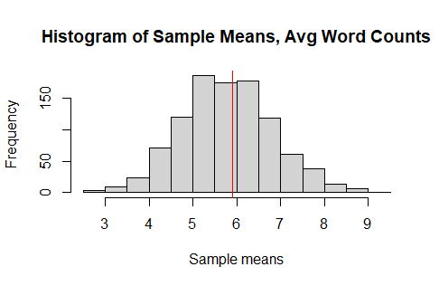

- Each of you calculated your own sample mean of the word count in the Carleton Mission Statement
- Our samples were biased, but I created some unbiased samples using R, shown here
- Return to this idea to quantify the *uncertainty* in our estimation process.

# Sampling Distribution

## Sampling Distribution

**Sampling Distribution:** the distribution of *sample statistics* computed for different samples of the **same size** from the **same population**

What does this tell us?

- Shows how the sample statistic **varies** from sample to sample
- Therefore, allows us to **quantify uncertainty**

## Role of Center and Shape

**Center**

If samples are **randomly** selected from the population, the sampling distribution should be **centered** *around the population parameter*.

**Shape**

For most of the statistics we consider, if the sample size is large enough, the sampling distribution will be **symmetric and bell-shaped**.

## Uncertainty Quantification

**Standard Error**

The **standard error** of a statistic (SE) is the standard deviation of the sample statistic.

- Standard error measures how much the statistic varies from sample to sample

## Carleton Mission: Simulated Avg Word Lengths

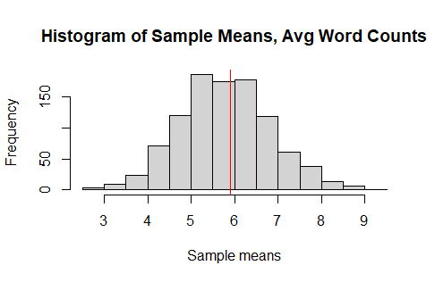

The standard error for the **average word size** in a random sample of 10 words is closest to: (Remember the 95% rule)

1. 0.5
2. 1
3. 2

Middle 95% of samples (4 SEs) means goes from approx 4 to 8, meaning SE $\approx$ 4/4 = 1

## Sample size matters!

**Role of sample size**

As the sample size **increases**, the variability (SE) of the sample statistics tends to **decrease.**

A smaller SE means that the sample statistics tend to be closer to the true population parameter

## Carleton Mission Example

What was the sample size, conceptually? (for est. avg word length)

- Number of words

Two sets of data below:

- Many sample means, all from samples of size 10
- Many sample means, all from samples of size 40
- The same number of sample means (1,000) for each set

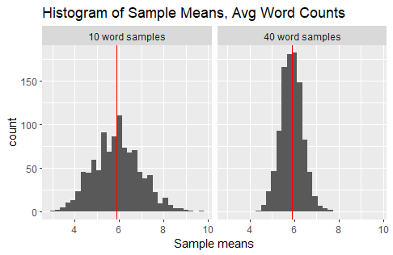

Variability in sampling dist goes down as sample size goes up!

## Other factors

What else might affect the standard error of a statistic?

Variability of a population

- **Quantitative variable**: the larger the population standard deviation, the larger the standard error of a statistic (such as a sample mean)
- **Categorical variable**: the closer the population proportion is to 0.5, the larger the standard error of the sample proportion

## Sample Size vs Simulation Size

!!! Sample size and simulation size are different! !!!

- **Sample size (n)**: number of individuals/cases in our sample used to compute the statistic
  - The SE of the statistic gets smaller as $n$ gets bigger
- **Simulation size**: number of random samples taken from the population to simulate the sampling distribution of our statistic
  - Usually a couple hundred samples is sufficient to show shape/spread/center

## Sampling Distributions as Dot Plots

Dotplots:

- Similar to histograms, show the distribution of a statistic
- Each dot represents a statistic calculated from a sample (ex: $\bar{x}$)
- **Statkey** will use dot plots to show distributions (in the handout)

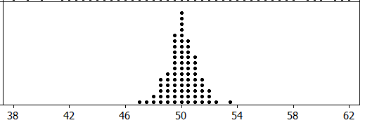

## Statkey

Where to find the standard error of a sampling distribution in Statkey

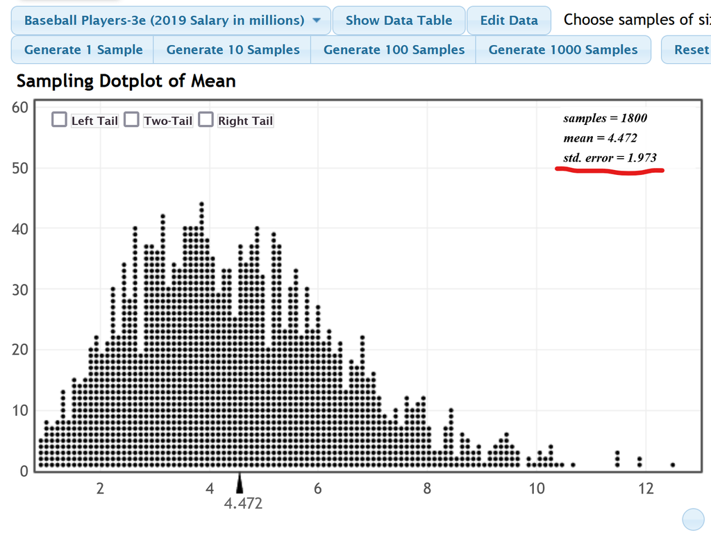

## Statkey

Let’s work through Example 1 (and 2, if you have time) in your groups using the Handout. I suggest having **one person** pull up Statkey and you can discuss the interpretation for the handout problems.

**Example 1:** You’ll need to change the sample size to 200! (By default it is 100.)

www.lock5stat.com/StatKey/

## Summary

**Summary of 3.1**

- **Statistical Inference** is drawing conclusions about a population based on a sample
- We use a sample statistic to estimate a population parameter
- To assess the uncertainty of a statistic, we need to know how much the statistic **varies** from sample to sample
- To create a **sampling distribution**, take many samples of the same size from the population, and compute the statistic for each
  - Need **random samples** for the sampling distribution to be centered at the population parameter
- **Standard error** is the standard deviation of a statistic

## Next Class

Estimating parameters with confidence (intervals)

- **Problem**: in the real world, we only have one sample
- We still can estimate the SE with only one sample!